| title: “Doing model interpretation in parallel” |
| --- |
| output: rmarkdown::html_vignette |
| vignette: > |
| % |
| % |

The `iml` package can now handle bigger datasets. Earlier problems with exploding memory have been fixed for `Partial`, `FeatureImp` and `Interaction`. It’s also possible now to compute `FeatureImp` and `Interaction` in parallel. This document describes how.

First we load some data, fit a random forest and create a Predictor object.

```r
set.seed(42)
library("iml")
library("randomForest")
data("Boston", package  = "MASS")
rf = randomForest(medv ~ ., data = Boston, ntree = 500)
X = Boston[which(names(Boston) != "medv")]
predictor = Predictor$new(rf, data = X, y = Boston$medv)
```

## Going parallel

You need to install the `doParallel` or a similar framework to compute in parallel. Before you can use parallelization to compute for example the feature importance on multiple CPU cores, you have to setup up a cluster. Fortunately, the `doParallel` makes it easy to setup and register a cluster:

```r
library("doParallel")
# Creates a cluster with 4 cores
cl = makePSOCKcluster(4)
# Registers cluster
registerDoParallel(cl)
```

Now we can easily compute feature importance in parallel. This means that the computation per feature is distributed among the 4 cores I specified earlier.

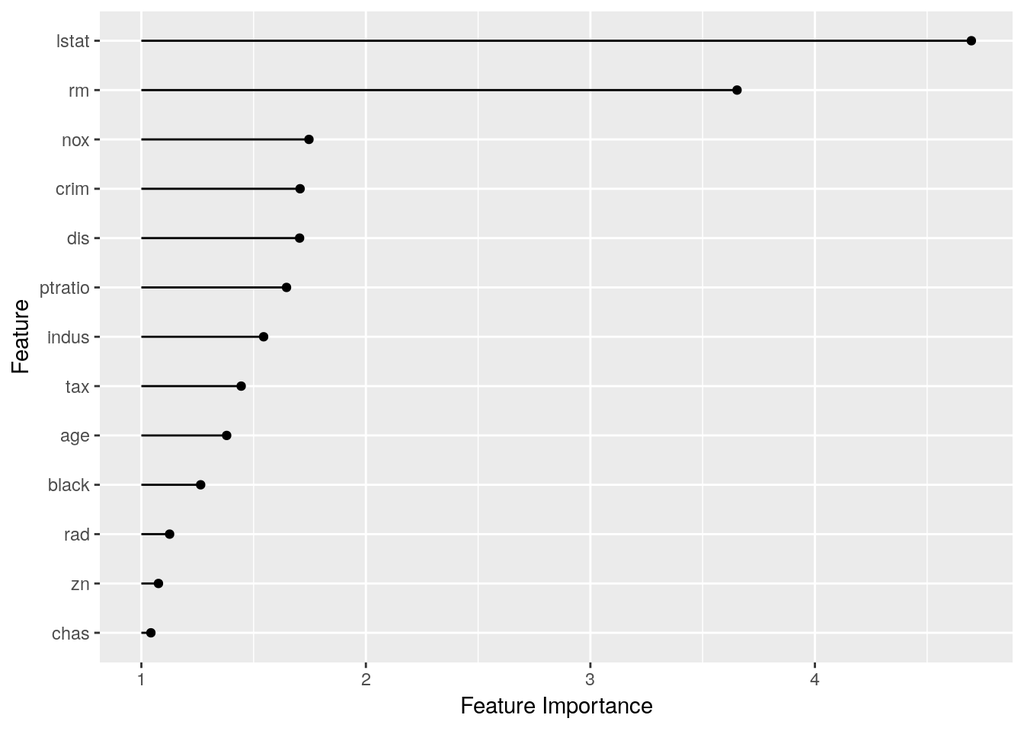

```r
imp = FeatureImp$new(predictor, loss = "mae", parallel = TRUE)
plot(imp)
```

That wasn’t very impressive, let’s actually see how much speed up we get by parallelization.

```r
system.time(FeatureImp$new(predictor, loss = "mae", parallel = FALSE))
```

```
#>    user  system elapsed
#>   1.188   0.020   1.236
```

```r
system.time(FeatureImp$new(predictor, loss = "mae", parallel = TRUE))
```

```
#>    user  system elapsed
#>   0.152   0.044   1.317
```

```r
system.time(FeatureImp$new(predictor, loss = "mae", parallel = FALSE, n.repetitions = 200))
```

```
#>    user  system elapsed
#>  57.648   0.028  57.759
```

```r
system.time(FeatureImp$new(predictor, loss = "mae", parallel = TRUE, n.repetitions = 200))
```

```
#>    user  system elapsed
#>   0.128   0.008  23.920
```

Here the parallel computation is twice as fast as the sequential computation of the feature importance.

The parallization also speeds up the computation of the interaction statistics:

```r
system.time(Interaction$new(predictor, parallel = FALSE))
```

```
#>    user  system elapsed
#>  12.324   0.008  12.331
```

```r
system.time(Interaction$new(predictor, parallel = TRUE))
```

```
#>    user  system elapsed
#>   0.136   0.020   6.401
```

Remember to stop the cluster in the end again.

```r
stopCluster(cl)
```